# Coursework Report

*N* removed NAs: 3

*N* removed typo: 1

*N* removed <18: 46

[output not shown]

**Main analysis results**

*t*(98) = -3.82, *p* < .001

[interactive chart not shown]

[figure not shown]

[interactive chart not shown]

# Coursework Report

Analysing Data, Spring 2020

# Methods

## Participants

Table 1: Information about particpants

| Group | N | Mage | SDage | Minage | Maxage |
| --- | --- | --- | --- | --- | --- |
| control | 42 | 20.6 | 1.89 | 18 | 25 |
| experimental | 57 | 20.8 | 1.85 | 18 | 25 |

## Design

This study is a replication of Elliot et al. (2010) experiment, which investigates whether the colour red influences the perceived attractiveness of a person, more specifically it examines if women’s judgment of men varies when associated with the colour red.

Participants were randomly assigned to one of two groups, the experimental and the control group. Each participant was shown a picture of a young Caucasian man surrounded by a frame of colour, white for the participants in the control group and red for the ones in the experimental group. Then they were asked a set of three questions regarding how attractive they found the man in the picture, they had to answer using a scale graded from 1-9. From these answers, we were able to calculate a composite score, which allows us to observe the mean difference between the groups. From this, we can examine if the difference in means is substantially significant by using the *t*-test.

We expect the results to indicate that the man presented with the red background will be given higher ratings on his appearance by the participants.

# Results

In this study, we investigated whether the colour red can influence the way women rate a man’s appearance. After observing an image, the participants answered 3 questions regarding the man’s attractiveness, from this we calculated the mean attractiveness for the control and experimental group (seen in Table 2). By observing the data, we can notice a mean difference of 0.51 between the two groups. We also observe a difference in the groups when examining the graph (see Graph 1). This suggests that the image of the man on the red background is rated as more attractive.

To be more rigorous in our research and to see if the mean difference is significant, we used the *t*-test. From this we can observe that, as predicted, the image contoured in red had a higher mean rate of attraction ( *M*= 6.3 ) compared to the white background (*M* = 5.79 ). From the *t*-test we can also observe that the difference between the means is substantial (*M*<sub>diff</sub> = -0.514, 95% CI [ -0.8, -0.24]).

Moreover, for the confidence interval, both groups results are lower than 0, this indicates that the true mean difference cannot be 0, which shows there is a difference in perceived attractiveness depending on the colour that surrounds the image.

Furthermore the *p*value = .0004, since it’s less than .05 we can accept the alternative hypothesis, meaning that the colour red can have an effect on the perceived attractiveness of a person.

Table 2: The calculated mean results for each category

| Group | N | Mquestion1 | Mquestion2 | Mquestion3 | Mattractiveness |
| --- | --- | --- | --- | --- | --- |
| control | 42 | 5.90 | 5.81 | 5.64 | 5.79 |
| experimental | 57 | 5.86 | 6.63 | 6.42 | 6.30 |

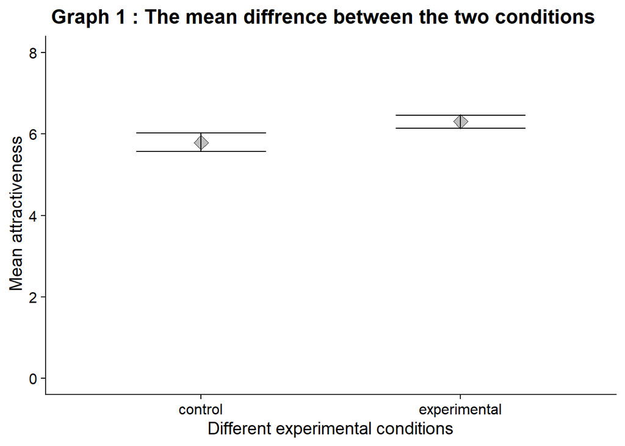

# Discussion

This study was a replication of the Elliot et al. (2010) study, which examined the effect the colour red has on the way women perceive a man’s attractiveness. There is a substantial mean difference between the red and white background, meaning having a red background increases substantially the ratings of the man’s attractiveness. The significance of this mean difference was found by using a statistical test, in this case it was the *t*-test. Our results show that the colour red has a positive influence on attractiveness. This means we can accept the alternative hypothesise, so the presence of red does make the man appear more attractive to women.

The findings of our experiment support the alternative hypothesis. In addition, our results are in accordance with those found in the original study. This can be perceived as positive, as repeated testing helps validate studies. It is especially beneficial when the results show similar findings. Furthermore, the original study was conducted in more countries and had a higher number of participants, making the findings even more significant (Elliot & Maier, 2013).

This study is just one of many replicas of the Elliot et al. (2010) experiment, and one of many experiments studying the colour in context theory. As colour in context theory is a popular topic to study when trying to identify what can influence the way humans perceive potential mates (Hesslinger et al., 2015). Since many primates, especially those closely related to humans, are influenced by the presence of colours when choosing a mate, it reinforces the idea that humans can also be influenced by colour when choosing a partner (Beall & Tracy, 2013). Furthermore, within many cultures and throughout history the colour red has often been associated with nobility and high social status, which can be an appealing trait for women looking for a companion (Elliot et al., 2010). There are many reasons to believe colour, especially red, can influence a person’s judgment of someone.

However, most of the studies that replicated Elliot et al. (2010) have found negative results, meaning they did not observe a link between the colour red and the perceived attractiveness of others. For them, the null hypothesis was accepted. In Hesslinger et al. (2015) ‘s study, they also tried to replicate Elliot et al. (2010) experiment, they found no significant statistical difference between the different coloured backgrounds. Nonetheless, they found that other factors, such as the different types of apparel, can have a significant effect on the attractiveness rating of the men (Hesslinger et al., 2015). Studies have also tested the theory with the opposite gender, they wanted to know if men find women in red more attractive. This study was also unsuccessful in demonstrating the red effect, although women were said to appear more sexually attractive, but not vis-versa (Peperkoorn et al., 2016).

Additionally, there have been some critical reviews of the original study. It has been observed that it lacks ecological validity, that the result analysis was only interpreted in a specific way and that there was publication bias (Francis, 2010). In addition, there are many studies that contradict Elliot et al. (2010) findings, meaning our result interpretation cannot be validated, and the way the study was conducted should be evaluated.

This study was also met with its own limitation which could have influenced the results. Firstly, there was a small amount of participant that took part in the experiment. In addition, they were all remarkably similar, meaning they consisted of women that are in their early 20’s. Additionally, our study only investigated one aspect of attraction. This means it is not a true representation of the populations, making it difficult to relate our results to the real world, diminishing the ecological validity. However, the experiment was conducted in a proper way, and the statistical analysis did confirm the hypothesis. Nonetheless, the limitation combined with the overwhelming number of studies that refute Elliot et al. (2010) findings, makes it difficult to conclude that red does have an actual effect on men’s attractiveness.

In summary, with this study the results showed support for the red effect, women did tend to find men on a red background more attractive. However, there are many reasons that lead us to believe improvements need to be made in terms of the hypothesis, and the experimental method, to allow a satisfactory conclusion. Therefore, further studies should be conducted investigating the red effect, by focusing on aspects that show more promising results. Such as, analyzing the fact that red might influence sexual attraction, in a short-relationship context (Hesslinger et al., 2015). Future studies should try to replicate or further the research by taking on a different approach to the red effect.

# References

Beall, A. T., & Tracy, J. L. (n.d.). Women Are More Likely to Wear Red or Pink at Peak Fertility. 5.

Elliot, A. J., Kayser, D. N., Greitemeyer, T., Lichtenfeld, S., Gramzow, R. H., Maier, M. A., & Liu, H. (n.d.). Red, Rank, and Romance in Women Viewing Men. 19.

Elliot, A. J., & Maier, M. A. (n.d.). The Red-Attractiveness Effect, Applying the Ioannidis and Trikalinos (2007b) Test, and the Broader Scientific Context: A Reply to Francis (2013). 4.

Francis, G. (2010). Publication Bias in “Red, Rank, and Romance in Women Viewing Men,” by Elliot et al. (2010). 5.

Hesslinger, V. M., Goldbach, L., & Carbon, C.-C. (2015). Men in red: A reexamination of the red-attractiveness effect. Psychon Bull Rev, 7.

Revisiting the Red Effect on Attractiveness and Sexual Receptivity. (n.d.). Evolutionary Psychology, 13.